# DS5220 Project 1

```r
# using continuous variable displ to aesthetic shape
# ggplot(data = mpg) +
#   geom_point(mapping = aes(x = displ, y = hwy, shape=mpg$displ), shape=mpg$displ )

# ggplot(data = mpg) +
#   geom_point(mapping = aes(x = displ, y = hwy, shape=displ))
```

Mapping `displ` to `color` and `size` produce meaningful results. Mapping `displ` to `shape` produces a warning. Assigning the aesthetic `shape` to `fl` produces the following.

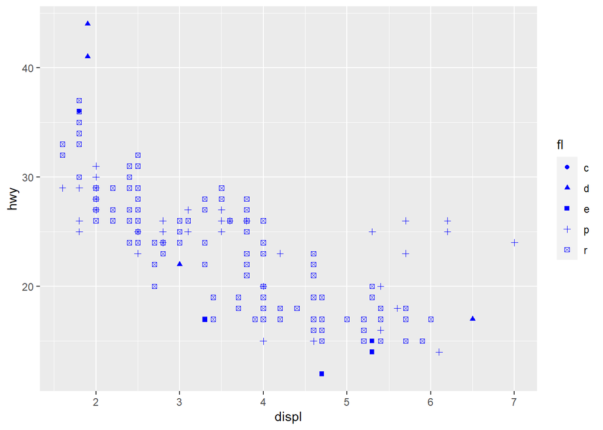

```r
# using categorical variable fl to aesthetic shape
ggplot(data = mpg) +
  geom_point(mapping = aes(x = displ, y = hwy, shape=fl), color = "blue")
```

4. What happens if you map the same variable to multiple aesthetics? Use an example from your answers to problem 3.3.1.3.

Mapping the same variable to different aesthetics produces an output without any error. although the information that is presents seems to be redundant.

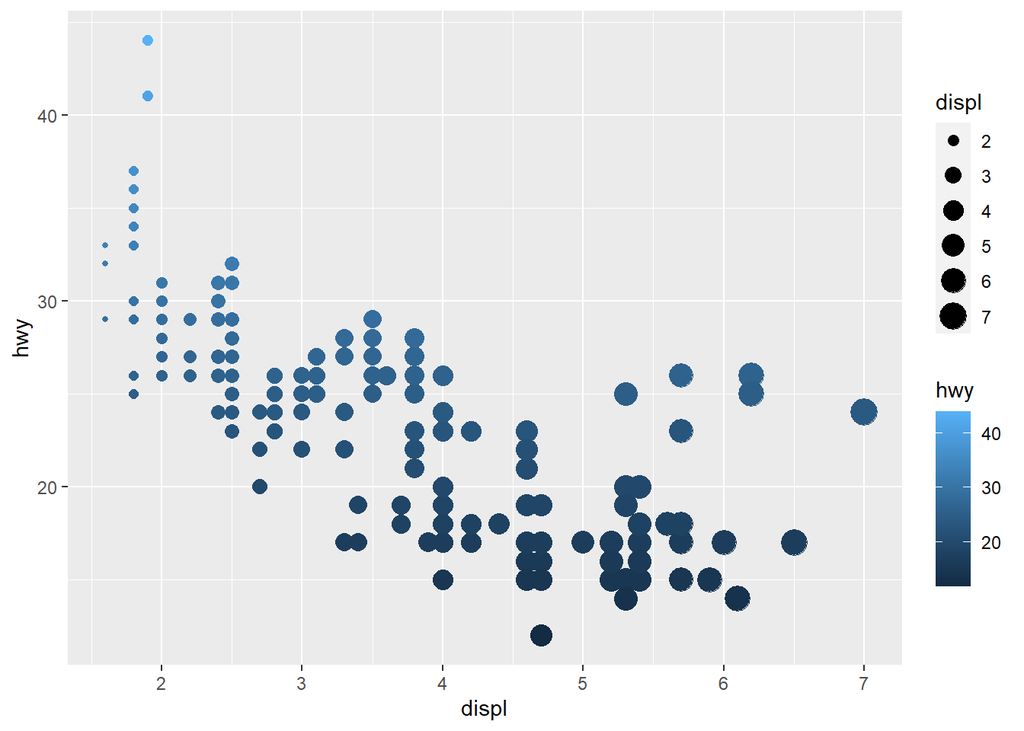

```r
ggplot(data=mpg) +
  geom_point(mapping = aes(x = displ, y = hwy, color=hwy, size=displ))
```

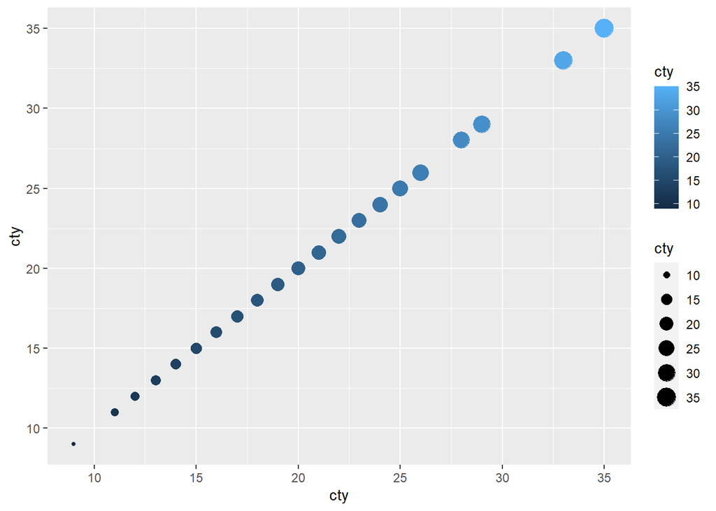

```r
ggplot(data=mpg) +
  geom_point(mapping = aes(x = cty, y = cty, color=cty, size=cty))
```

5. What does the `stroke` aesthetic do? What shapes does it work with? (Hint: use`?geom_point`) Try it with `shape=21` and `stroke=displ` in your code from 3.3.1.1.

Stroke defines the thickness of the border.It works for shapes 21-24. They have both stroke color and a fill.

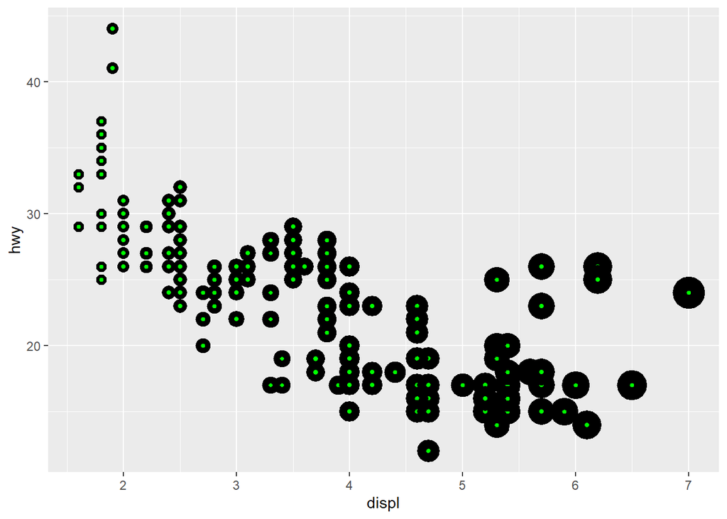

```r
ggplot(data = mpg) +
  geom_point(mapping = aes(x = displ, y = hwy, stroke=displ), shape=21, fill="green")
```

6.What happens if you map an aesthetic to something other than a variable name, like `aes(colour = displ < 5)`? Try this by modifying your code in problem 3.3.1.1.

displ<5 acts as a logical expression and returns true or false. geom_point colors the plot based on the true and false values. There is also a legend for the same.

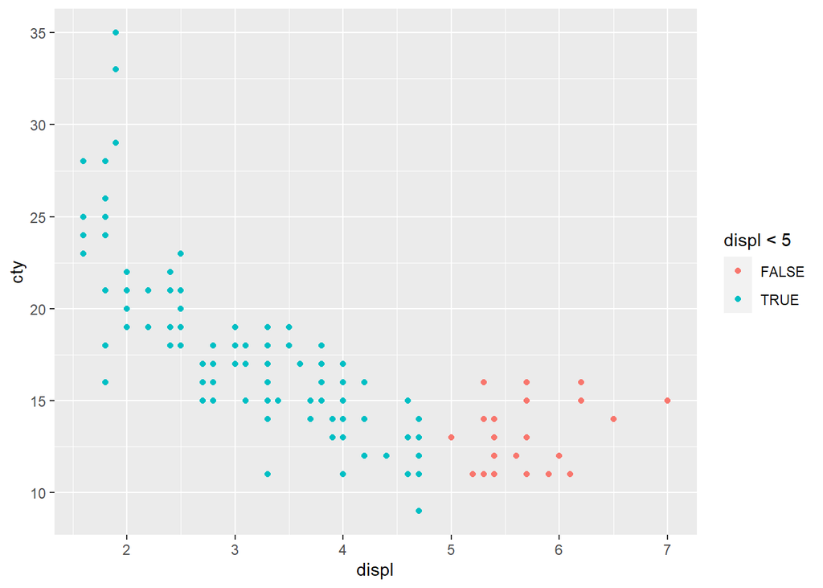

```r
ggplot(data=mpg) +
  geom_point(mapping = aes(x=displ, y=cty, color = displ<5))
```

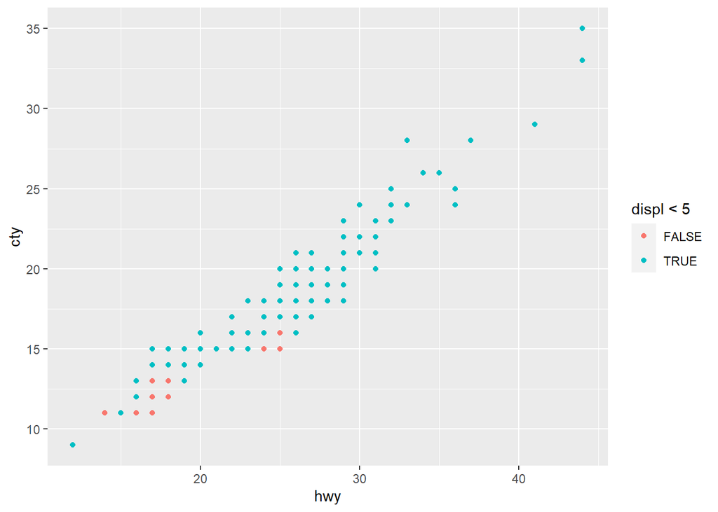

```r
ggplot(data=mpg) +
  geom_point(mapping = aes(x=hwy, y=cty, color = displ<5))
```